# Tehtävä 4

## Johdanto

Tässä osassa katsotaan, mitä tapahtuu eli kuinka paljon arktisen alueen lämpötila muuttuu, jos jatketaan nykyisellä linjalla.

## Aineiston valmistaminen

Ensin lasketaan jokaisen vuoden arktisen alueen keskilämpotila. Arktisella alueella tarkoitetaan maapallon osan, joka sijatsee 66. ja sitä pohjaisimmilla leveysasteilla.

```r
data <- read.csv(file="data.csv", header=TRUE)

last_year <- max(data$year)
average_temp <- NA
for(year_i in 1900:last_year) {
  m <- mean(as.matrix(data[data$year == year_i & data$latitude > 65,3:14]))
  average_temp <- c(average_temp, m)
}

average_temp<- average_temp[2:length(average_temp)]
```

Luodaan aikasarja.

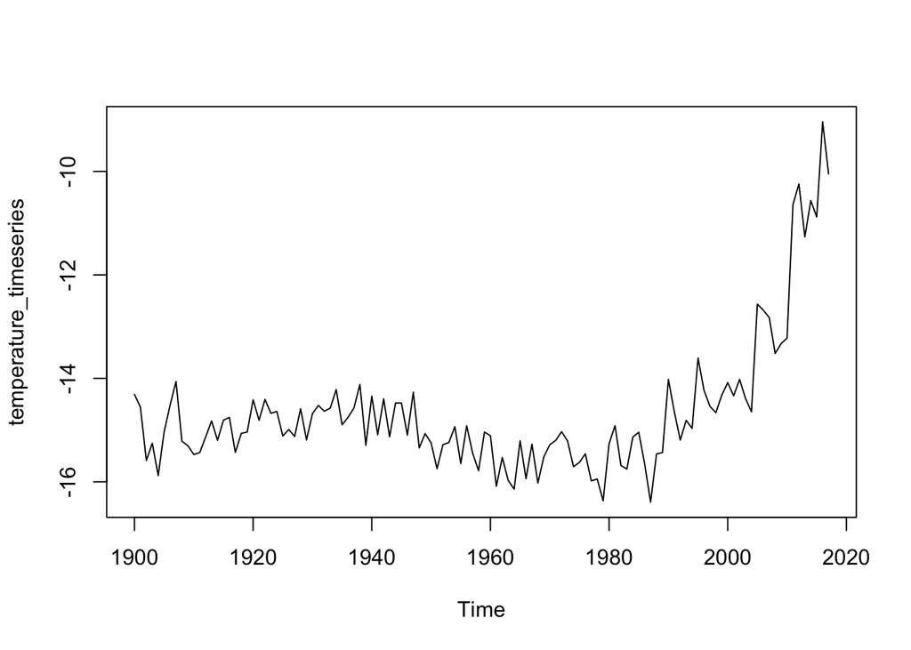

```r
temperature_timeseries <- ts(average_temp, start = 1900)
plot.ts(temperature_timeseries)
```

## Analyysoidaan

Olen tutustunut kahteen erillaiseen menetelmään, HoltWinters ja AMIRA. Käytetään ne molemmat ja katsotaan mistä menetelmästä saadaan luotettavimpia tuloksia.

### HoltWinters

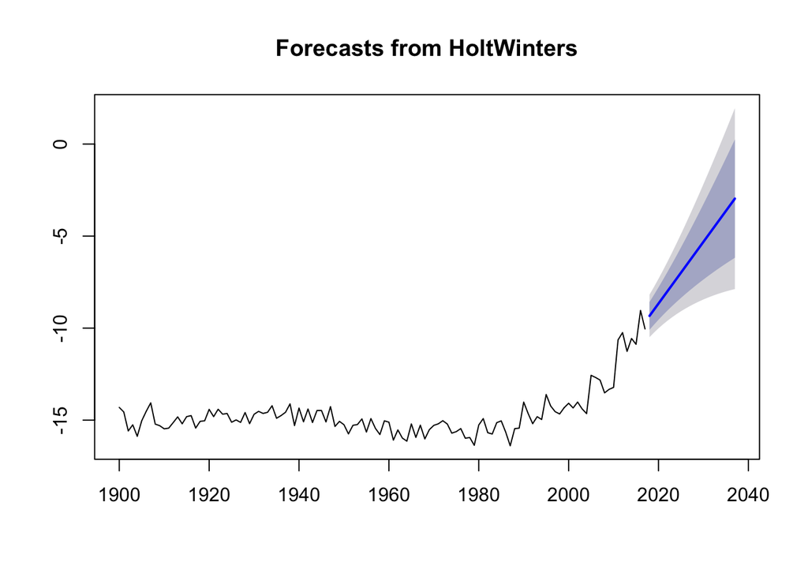

```r
temperature_forecast <- HoltWinters(temperature_timeseries, gamma=FALSE)

temperature_forecast_HW <- forecast( temperature_forecast, h = 20)
plot(temperature_forecast_HW)
```

Saadaan tulokseksi, että keskimääräinen lämpötila jatkaa voimakkaasti kasvua. Tämän ennusteen mukaan vuoden 2030 arktisen alueen keskimääräinen lämpötila on -5.3 astetta ja 95% luottamusväli on [-7.360322, -3.2637091].

95% luottamusväli on merkitty harmaalla värillä kuvassa.

Kuitenkin meidän on tarkistettava, ettei mallissamme ole autokorrelatioita.

```r
Box.test(temperature_forecast_HW$residuals, lag=20, type="Ljung-Box")
```

```
##
##  Box-Ljung test
##
## data:  temperature_forecast_HW$residuals
## X-squared = 28.077, df = 20, p-value = 0.1076
```

### ARIMA

Tämä metodi ei vaadi korreloittomuutta. Kun korrelaatioita esiintyy, se ottaa ne huomioon.

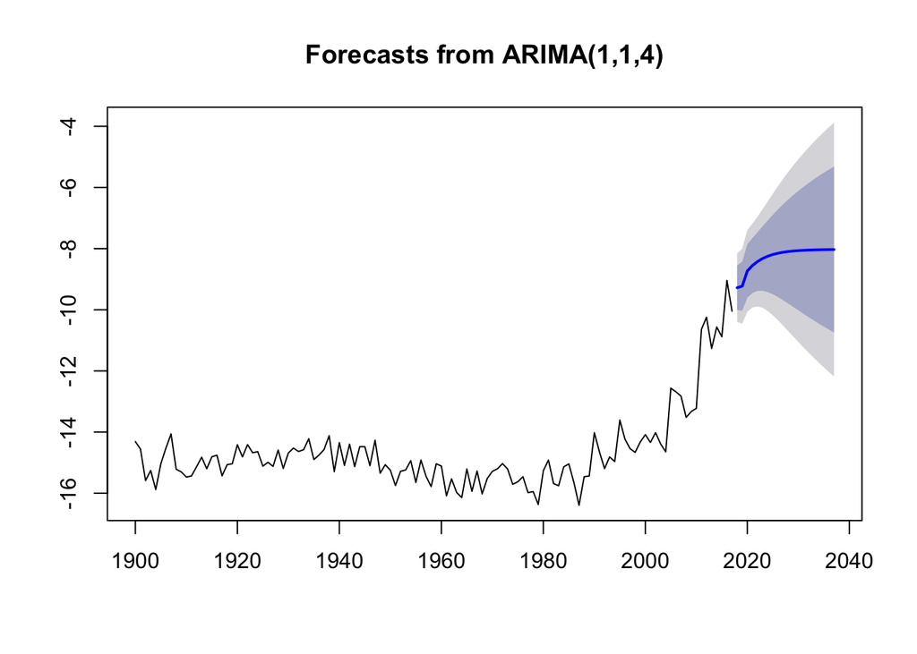

```r
temperature_arima <- auto.arima(temperature_timeseries)
temperature_forecast_arima <- forecast( temperature_arima, h = 20)
plot(temperature_forecast_arima)
```

Nyt päädytään tulokseen, että lämpötilan kasvu hidastuu. Vuonna 2030 ennuste keskilämpötilalle on -8.1 ja 95% luottamusväli on [-11.053271, -5.076842].